# Cyclistic Bike Share Analysis

*Du Pham*

```r
paste("First created on July 15, 2021. Updated on", Sys.Date())
```

'First created on July 15, 2021. Updated on 2021-07-21'

**Goal:** Provide graphs about how casual riders and annual members use Cyclistic bikes differently so that the team can come up with appropriate stategies to maximize the number of annual memberships.

## 1. Data Preparation:

#### Read the data .csv files

```r
options(warn=-1)
library(tidyverse)
library(readr)
```

```r
mydir  <-  "Divvy_Trips"
myfiles  <- list.files(path=mydir, pattern="*.csv", full.names=TRUE)
myfiles
```

1. 'Divvy_Trips/Divvy_Trips_2019_Q1.csv'

2. 'Divvy_Trips/Divvy_Trips_2019_Q2.csv'

3. 'Divvy_Trips/Divvy_Trips_2019_Q3.csv'

4. 'Divvy_Trips/Divvy_Trips_2019_Q4.csv'

```r
for (f in myfiles){
                                dat  <-  read_csv(f)
}
```

#### See the data type and the first few row of data.

```r
glimpse(dat)
```

```
Rows: 704,054
Columns: 12
$ trip_id           <dbl> 25223640, 25223641, 25223642, 25223643, 25223644, 25~
$ start_time        <dttm> 2019-10-01 00:01:39, 2019-10-01 00:02:16, 2019-10-0~
$ end_time          <dttm> 2019-10-01 00:17:20, 2019-10-01 00:06:34, 2019-10-0~
$ bikeid            <dbl> 2215, 6328, 3003, 3275, 5294, 1891, 1061, 1274, 6011~
$ tripduration      <dbl> 940, 258, 850, 2350, 1867, 373, 1072, 1458, 1437, 83~
$ from_station_id   <dbl> 20, 19, 84, 313, 210, 156, 84, 156, 156, 336, 77, 19~
$ from_station_name <chr> "Sheffield Ave & Kingsbury St", "Throop (Loomis) St ~
$ to_station_id     <dbl> 309, 241, 199, 290, 382, 226, 142, 463, 463, 336, 50~
$ to_station_name   <chr> "Leavitt St & Armitage Ave", "Morgan St & Polk St", ~
$ usertype          <chr> "Subscriber", "Subscriber", "Subscriber", "Subscribe~
$ gender            <chr> "Male", "Male", "Female", "Male", "Male", "Female", ~
$ birthyear         <dbl> 1987, 1998, 1991, 1990, 1987, 1994, 1991, 1995, 1993~
```

```r
head(dat)
```

| trip_id | start_time | end_time | bikeid | tripduration | from_station_id | from_station_name | to_station_id | to_station_name | usertype | gender | birthyear |
| --- | --- | --- | --- | --- | --- | --- | --- | --- | --- | --- | --- |
| 25223640 | 2019-10-01 00:01:39 | 2019-10-01 00:17:20 | 2215 | 940 | 20 | Sheffield Ave & Kingsbury St | 309 | Leavitt St & Armitage Ave | Subscriber | Male | 1987 |
| 25223641 | 2019-10-01 00:02:16 | 2019-10-01 00:06:34 | 6328 | 258 | 19 | Throop (Loomis) St & Taylor St | 241 | Morgan St & Polk St | Subscriber | Male | 1998 |
| 25223642 | 2019-10-01 00:04:32 | 2019-10-01 00:18:43 | 3003 | 850 | 84 | Milwaukee Ave & Grand Ave | 199 | Wabash Ave & Grand Ave | Subscriber | Female | 1991 |
| 25223643 | 2019-10-01 00:04:32 | 2019-10-01 00:43:43 | 3275 | 2350 | 313 | Lakeview Ave & Fullerton Pkwy | 290 | Kedzie Ave & Palmer Ct | Subscriber | Male | 1990 |
| 25223644 | 2019-10-01 00:04:34 | 2019-10-01 00:35:42 | 5294 | 1867 | 210 | Ashland Ave & Division St | 382 | Western Ave & Congress Pkwy | Subscriber | Male | 1987 |
| 25223645 | 2019-10-01 00:04:38 | 2019-10-01 00:10:51 | 1891 | 373 | 156 | Clark St & Wellington Ave | 226 | Racine Ave & Belmont Ave | Subscriber | Female | 1994 |

#### We want to find if there is any COLUMNS with null values

```r
NA_cols <- sapply(dat, function(x) sum(is.na(x)))
NA_cols[NA_cols>0]
```

**gender**

66591

**birthyear**

61681

The missing data are in columns gender and birthyear which do not carry important numeric information for the analysis. *We decide to leave the data as is.*

## 2. Analysis:

- We first find the mean, median of bike share usages for casual riders (customers) and annual members (subscibers). We use summary command for each of the entries in usertype (customers, subscibers)

```r
l <- as.list(strsplit(unique(dat$usertype)," "))
# print(l)
# typeof(l)
for (name in l){
                                cmd  <- sprintf("----------- usertype = % s -----", name)
                                print(eval(cmd))
                                d <- dat  %>%     filter(usertype==name)

#   print(count(d, 'tripduration') )
                                print(summary(d[5]))

}
```

```
[1] "----------- usertype = Subscriber -----"
  tripduration
 Min.   :     61
 1st Qu.:    330
 Median :    528
 Mean   :    749
 3rd Qu.:    851
 Max.   :5169622
[1] "----------- usertype = Customer -----"
  tripduration
 Min.   :     61
 1st Qu.:    727
 Median :   1283
 Mean   :   3665
 3rd Qu.:   2135
 Max.   :8585902
```

We observe that the mean and median usage of the casual riders are 3,665 and 1,283, which are much higher than those of annual members, 749 and 528 resp.

#### We now partition the users into groups of specific time windows and carry the plots to compare the numbers of users between the casual and annual riders.

```r
dat <- dat %>%
                                mutate(duration_group = case_when(
#     tripduration <= 60 ~ "a. <= 1h",
                                tripduration <= 60*8 ~ "a. <= 8h",
                                tripduration <= 60*24 ~ "b. 8-24h",
                                tripduration <= 60*168 ~ "c. 1d- 1w",
                                tripduration <= 60*4704 ~ "d. 1-4w",
                                TRUE ~ "e. > 4w"
                                ))

dat <- dat %>%
                                mutate(duration_day = tripduration/(24*60))
```

```r
dat %>%
                                filter(usertype=="Customer") %>%
                                group_by(duration_group) %>%
                                summarise_at(vars(tripduration), funs(n(),mean(., na.rm=TRUE),median(., na.rm=TRUE),sd(., na.rm=TRUE) ))
```

| duration_group | n | mean | median | sd |
| --- | --- | --- | --- | --- |
| a. <= 8h | 12696 | 345.8951 | 360 | 9.311473e+01 |
| b. 8-24h | 46563 | 924.2205 | 903 | 2.732324e+02 |
| c. 1d- 1w | 44908 | 2956.3664 | 2275 | 1.721485e+03 |
| d. 1-4w | 1921 | 37481.1478 | 18453 | 4.299967e+04 |
| e. > 4w | 106 | 1292997.6981 | 643713 | 1.512685e+06 |

```r
dat %>%
                                filter(usertype=="Subscriber") %>%
                                group_by(duration_group) %>%
                                summarise_at(vars(tripduration), funs(n(),mean(., na.rm=TRUE),median(., na.rm=TRUE),sd(., na.rm=TRUE) ))
```

| duration_group | n | mean | median | sd |
| --- | --- | --- | --- | --- |
| a. <= 8h | 266973 | 308.5608 | 312.0 | 9.992137e+01 |
| b. 8-24h | 283339 | 801.5121 | 740.0 | 2.505926e+02 |
| c. 1d- 1w | 47095 | 1952.6450 | 1798.0 | 6.149719e+02 |
| d. 1-4w | 427 | 53480.4215 | 33989.0 | 5.308332e+04 |
| e. > 4w | 26 | 914154.7308 | 503003.5 | 1.250441e+06 |

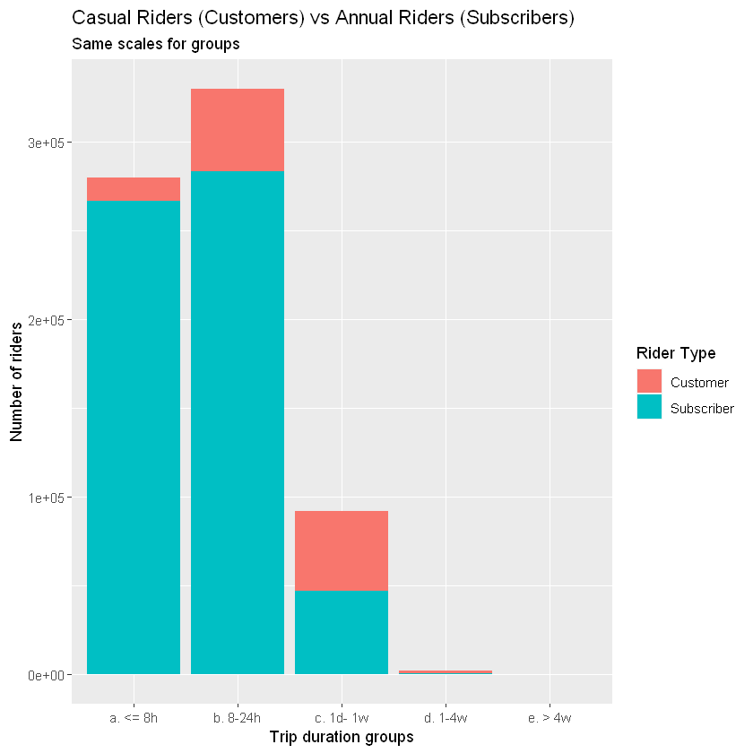

```r
ggplot(data = dat) +
#   geom_histogram(mapping = aes(x = tripduration),binwidth = 1000, color = "black", fill = "gray")
                                geom_bar(mapping = aes(x = duration_group,fill=usertype)) +
#   facet_wrap(~usertype) +
#   theme(axis.text.x = element_text(angle = 45)) +
                                xlab("Trip duration groups") +
                                ylab("Number of riders") +
                                labs(title = "Casual Riders (Customers) vs Annual Riders (Subscribers)",subtitle ="Same scales for groups", fill= "Rider Type")
```

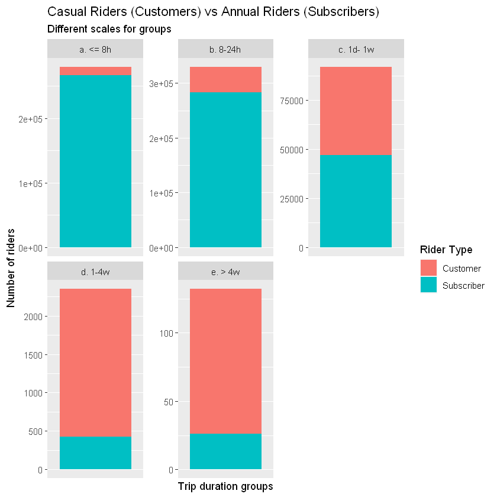

```r
ggplot(data = dat) +
#   geom_histogram(mapping = aes(x = tripduration),binwidth = 1000, color = "black", fill = "gray")
                                geom_bar(mapping = aes(x = duration_group,fill = usertype)) +
                                facet_wrap(~duration_group, scales = "free") +
                                scale_x_discrete(breaks= c("", "", "", "", ""))+
                                xlab("Trip duration groups") +
                                ylab("Number of riders") +
                                labs(title = "Casual Riders (Customers) vs Annual Riders (Subscribers)", subtitle ="Different scales for groups", fill= "Rider Type")
```

# 3. Conclusion

- By grouping data in short and long riders and comparing the bike share usage for each group, we see that the annual users are using the share bike service a whole lot more. We also see that they tend to use the service for everyday commute more.
- The conclusion is drawn both from graphs and data statistical summary.

# 4. Further Consideration

- Here the data is given in the trip id form. We can collect data in customer id form, where we can analyse how a casual rider's bike usage differs from annual user's one.
- We can analyse the bike usage of each age group for market target.